# Relatório: levantamento de pacientes com indicação para tratamento com TAF

Guilherme e Laura

21 setembro, 2022

# 1. Banco de Dados

|  | record_id | date_start_v2 | rghc_v2 | name_v2 | dob_v2 | age_v2 | height_v2 | weigth_v2 | imc_v2 | sex_v2 | etnia | dados_demogrficos_complete | tenofovir | start_date | lamivudina | pregnant_breastfeeding | cirrhosis | child | comorbidity___0 | comorbidity___1 | comorbidity___2 | comorbidity___3 | albumin_urine | protein_urine | serum_phosphate | immunosuppressive_therapy___1 | immunosuppressive_therapy___2 | immunosuppressive_therapy___3 | immunosuppressive_therapy___4 | … |
| --- | --- | --- | --- | --- | --- | --- | --- | --- | --- | --- | --- | --- | --- | --- | --- | --- | --- | --- | --- | --- | --- | --- | --- | --- | --- | --- | --- | --- | --- | --- |
| 1 | 1 | 2022-05-24 | 13878484C | ADAILTO BERNARDO DA SILVA | 1971-12-11 | 50.4 | 1.80 | 89.0 | 27.5 | M | Branca | 2 | 1 | 2010-04-06 | Não | 0 | Não | NA | Sim | Não | Não | Não | Não | Não | Não | 1 | 0 | 0 | 0 | … |
| 2 | 2 | 2022-05-24 | 13848842H | ADALBERTO APARECIDO GONCALVES | 1951-05-19 | 71.0 | 1.66 | 62.0 | 22.5 | M | Branca | 2 | 1 | 2009-04-09 | Sim | 0 | Não | NA | Não | Não | Não | Sim | Não | Não | Não | 1 | 1 | 0 | 0 | … |
| 3 | 3 | 2022-05-24 | 13814634K | ZENAIDE CORREA DE GODOI | 1946-09-23 | 75.6 | 1.60 | 92.0 | 35.9 | F | Branca | 2 | 1 | 2008-02-25 | Sim | 0 | Sim | 0 | Sim | Não | Não | Não | Não | Não | Não | 0 | 0 | 0 | 0 | … |
| 4 | 4 | 2022-05-24 | 14180562E | ADEMIR ALVES DE SOUZA | 1953-06-07 | 68.9 | 1.76 | 79.3 | 25.6 | M | Branca | 2 | 1 | 2021-05-17 | Não | 0 | Não | NA | Não | Não | Não | Sim | Não | Não | Não | 1 | 1 | 0 | 0 | … |
| 5 | 5 | 2022-05-24 | 13945793D | YUKIO YOSHIDA | 1951-07-31 | 70.8 | 1.71 | 72.3 | 24.7 | M | Amarela | 2 | 1 | 2011-03-03 | Não | 0 | Sim | 0 | Sim | Não | Não | Não | Não | Não | Não | 0 | 0 | 0 | 0 | … |
| 6 | 6 | 2022-05-24 | 3368510J | AFONSO SOARES NETO | 1956-03-26 | 66.1 | 1.65 | 71.0 | 26.1 | M | Branca | 2 | 1 | 2017-08-17 | Sim | 0 | Sim | 0 | Sim | Não | Não | Não | Não | Não | Não | 0 | 0 | 0 | 0 | … |
| 7 | 7 | 2022-05-24 | 13600011G | WILSON DE SOUSA ARAUJO | 1969-10-19 | 52.5 | 1.68 | 73.0 | 25.9 | M | Branca | 2 | 1 | 2014-05-08 | Sim | 0 | Sim | 0 | Sim | Não | Não | Não | Não | Não | Não | 1 | 0 | 0 | 0 | … |
| 8 | 8 | 2022-05-24 | 14266151K | ALAN SILVA DE OLIVEIRA | 1985-07-12 | 36.8 | 1.76 | 68.0 | 22.0 | M | Negra | 2 | 1 | 2020-04-09 | Sim | 0 | Não | NA | Sim | Não | Não | Não | Não | Não | Não | 0 | 0 | 0 | 0 | … |
| 9 | 9 | 2022-05-24 | 55380475C | WILMAR GUILHERME BARBOSA | 1958-10-25 | 63.5 | 1.63 | 78.4 | 29.5 | M | Branca | 2 | 1 | 2010-12-01 | Não | 0 | Sim | 0 | Não | Sim | Sim | Sim | Não | Não | Não | 0 | 0 | 0 | 0 | … |
| 10 | 10 | 2022-05-26 | 3236410E | WANDERLEY JACHINOVSKI | 1953-10-25 | 68.5 | 1.73 | 101.0 | 33.7 | M | Branca | 2 | 1 | 2019-07-25 | Sim | 0 | Sim | 0 | Não | Sim | Não | Sim | Não | Não | Não | 0 | 0 | 0 | 0 | … |

[output cut: 222 more lines]

# 2. Análise Descritiva

## Tabelas

**Tabela 1** - Características dos pacientes de acordo com os grupos de tratamento

| **Características** | **N** | **Total**<sup>1</sup> | **Grupos de Tratamento** **TAF**<sup>1</sup> | **Grupos de Tratamento** **TDF**<sup>1</sup> | **p**<sup>2</sup> |  |
| --- | --- | --- | --- | --- | --- | --- |
| Demográficas |  |  |  |  |  |  |
| Idade | 225 | 57 (46, 68) | 65 (53, 70) | 52 (44, 64) |  | <0.001 |
| IMC | 225 | 26.0 (23.5, 28.6) | 26.2 (23.8, 28.8) | 25.9 (23.4, 28.4) | 0.3 |  |
| Homem | 225 | 147 (65%) | 46 (57%) | 101 (70%) | 0.067 |  |
| Etnia | 214 |  |  |  | 0.7 |  |
| Branca |  | 158 (74%) | 59 (79%) | 99 (71%) |  |  |
| Negra |  | 14 (6.5%) | 3 (4.0%) | 11 (7.9%) |  |  |
| Amarela |  | 28 (13%) | 9 (12%) | 19 (14%) |  |  |
| Parda |  | 14 (6.5%) | 4 (5.3%) | 10 (7.2%) |  |  |
| Clínicas |  |  |  |  |  |  |
| Exposição à Lamivudina | 225 | 121 (54%) | 80 (100%) | 41 (28%) | <0.001 |  |
| Cirrose | 224 | 57 (25%) | 39 (49%) | 18 (12%) | <0.001 |  |
| Última TFGe <60 | 214 | 65 (30%) | 40 (53%) | 25 (18%) | <0.001 |  |
| Redução da TFGe >25% | 209 | 51 (24%) | 28 (37%) | 23 (17%) | 0.002 |  |
| Osteoporose | 224 | 19 (8.5%) | 12 (15%) | 7 (4.9%) | 0.009 |  |
| Comorbidades |  |  |  |  |  |  |
| Sem Comorbidades | 225 | 114 (51%) | 37 (46%) | 77 (53%) | 0.3 |  |
| Diabetes, tipo I ou II | 225 | 45 (20%) | 19 (24%) | 26 (18%) | 0.3 |  |
| Dislipidemia | 225 | 35 (16%) | 15 (19%) | 20 (14%) | 0.3 |  |
| Hipertensão | 225 | 90 (40%) | 38 (48%) | 52 (36%) | 0.088 |  |
| Creatinina Sérica |  |  |  |  |  |  |
| Prévia | 219 | 0.89 (0.74, 1.04) | 0.89 (0.70, 1.04) | 0.88 (0.76, 1.03) | 0.8 |  |
| Após | 220 | 0.90 (0.77, 1.03) | 0.92 (0.77, 1.08) | 0.90 (0.77, 0.99) | 0.4 |  |
| Última | 222 | 0.99 (0.85, 1.12) | 1.03 (0.88, 1.26) | 0.98 (0.83, 1.09) | 0.023 |  |

<sup>1</sup> Median (IQR); n (%)  
<sup>2</sup> Wilcoxon rank sum test; Pearson's Chi-squared test; Fisher's exact test

**Tabela 2** - Estimativas da taxa de filtração glomerular por MDRD², CKD-EPI e Cockcroft-Gault

| **Características** | **N** | **Total**<sup>1</sup> | **Grupos de Tratamento** **TAF**<sup>1</sup> | **Grupos de Tratamento** **TDF**<sup>1</sup> | **p**<sup>2</sup> |  |
| --- | --- | --- | --- | --- | --- | --- |
| MDRD² |  |  |  |  |  |  |
| Prévio | 219 | 86 (72, 102) | 84 (66, 93) | 88 (77, 104) |  | 0.022 |
| Após | 220 | 83 (70, 100) | 78 (61, 94) | 86 (75, 101) | 0.001 |  |
| Último | 222 | 73 (60, 87) | 62 (51, 82) | 78 (68, 90) | <0.001 |  |
| Redução da TFGe | 217 | 13 (4, 24) | 20 (8, 28) | 11 (2, 21) | <0.001 |  |
| CKD-EPI |  |  |  |  |  |  |
| Prévio | 219 | 99 (83, 108) | 93 (77, 105) | 100 (89, 111) | 0.008 |  |
| Após | 220 | 96 (81, 108) | 89 (69, 103) | 98 (87, 111) | <0.001 |  |
| Último | 222 | 82 (67, 98) | 68 (58, 91) | 87 (75, 100) | <0.001 |  |
| Redução da TFGe | 217 | 12 (5, 22) | 17 (8, 27) | 10 (4, 17) | <0.001 |  |
| Cockcroft-Gault |  |  |  |  |  |  |
| Último | 222 | 81 (63, 101) | 68 (51, 91) | 86 (71, 107) | <0.001 |  |

<sup>1</sup> Median (IQR)  
<sup>2</sup> Wilcoxon rank sum test

## Idade

```
## # A tibble: 3 x 3
##   status_patient `shapiro.test(age_v2)$statistic` `shapiro.test(age_v2)$p.value`
##   <chr>                                     <dbl>                          <dbl>
## 1 TAF                                       0.966                         0.0310
## 2 TDF                                       0.989                         0.346
## 3 <NA>                                      0.957                         0.796
```

```
## # A tibble: 1 x 4
##     df1   df2 statistic     p
##   <int> <int>     <dbl> <dbl>
## 1     1   223      1.05 0.306
```

```
##
##  Descriptive statistics by group
## group: TAF
##    vars  n  mean    sd median trimmed   mad  min  max range  skew kurtosis   se
## X1    1 80 62.08 12.19   65.3   62.85 12.38 32.6 88.4  55.8 -0.46    -0.51 1.36
## ------------------------------------------------------------
## group: TDF
##    vars   n  mean   sd median trimmed   mad  min  max range  skew kurtosis   se
## X1    1 145 53.09 13.8   52.2   53.39 14.23 19.8 83.7  63.9 -0.12    -0.55 1.15
```

```
## # A tibble: 3 x 4
##   status_patient quant25 quant50 quant75
##   <chr>            <dbl>   <dbl>   <dbl>
## 1 TAF               53.3    65.3    70
## 2 TDF               44.4    52.2    64.1
## 3 <NA>              49.7    58.5    62.1
```

### Mann-whitney Test

```
##
##  Wilcoxon rank sum test with continuity correction
##
## data:  dados$age_v2 by dados$status_patient
## W = 7985.5, p-value = 2.942e-06
## alternative hypothesis: true location shift is not equal to 0
```

## IMC

```
## # A tibble: 3 x 3
##   status_patient `shapiro.test(imc_v2)$statistic` `shapiro.test(imc_v2)$p.value`
##   <chr>                                     <dbl>                          <dbl>
## 1 TAF                                       0.936                       0.000602
## 2 TDF                                       0.968                       0.00171
## 3 <NA>                                      0.872                       0.192
```

```
## # A tibble: 1 x 4
##     df1   df2 statistic      p
##   <int> <int>     <dbl>  <dbl>
## 1     1   223      3.08 0.0808
```

```
##
##  Descriptive statistics by group
## group: TAF
##    vars  n mean  sd median trimmed  mad  min  max range skew kurtosis   se
## X1    1 80 26.9 5.2   26.2   26.47 3.71 17.2 46.7  29.5 1.06     2.04 0.58
## ------------------------------------------------------------
## group: TDF
##    vars   n  mean   sd median trimmed  mad min max range skew kurtosis   se
## X1    1 145 25.88 4.02   25.9   25.73 3.71  18  41    23  0.6     1.17 0.33
```

```
## # A tibble: 3 x 4
##   status_patient quant25 quant50 quant75
##   <chr>            <dbl>   <dbl>   <dbl>
## 1 TAF               23.8    26.2    28.8
## 2 TDF               23.4    25.9    28.4
## 3 <NA>              25.4    26.4    27.2
```

### Mann-whitney Test

```
##
##  Wilcoxon rank sum test with continuity correction
##
## data:  dados$imc_v2 by dados$status_patient
## W = 6286.5, p-value = 0.2984
## alternative hypothesis: true location shift is not equal to 0
```

## Sexo

### Frequência Absoluta Geral

```
##
##   M   F
## 149  83
```

### Frequência Relativa Geral

```
##
##  M  F
## 64 36
```

### Frequência Absoluta por Grupo

```
##
##     TAF TDF
##   M  46 101
##   F  34  44
```

### Frequência Relativa por Grupo

```
##
##     TAF TDF
##   M  58  70
##   F  42  30
```

### Teste Exato de Fisher

```
##
##  Fisher's Exact Test for Count Data
##
## data:  sex_ab
## p-value = 0.07938
## alternative hypothesis: true odds ratio is not equal to 1
## 95 percent confidence interval:
##  0.3219775 1.0839176
## sample estimates:
## odds ratio
##  0.5908138
```

## Etnia

### Frequência Absoluta Geral

```
##
##  Branca   Negra Amarela   Parda
##     161      14      29      14
```

### Frequência Relativa Geral

```
##
##  Branca   Negra Amarela   Parda
##      74       6      13       6
```

### Frequência Absoluta por Grupo

```
##
##           TAF TDF
##   Branca   59  99
##   Negra     3  11
##   Amarela   9  19
##   Parda     4  10
```

### Frequência Relativa por Grupo

```
##
##           TAF TDF
##   Branca   79  71
##   Negra     4   8
##   Amarela  12  14
##   Parda     5   7
```

### Teste Exato de Fisher

```
##
##  Fisher's Exact Test for Count Data
##
## data:  etnia_ab
## p-value = 0.6514
## alternative hypothesis: two.sided
```

## Cirrose

### Frequência Absoluta Geral

```
##
## Sim Não
##  57 172
```

### Frequência Relativa Geral

```
##
## Sim Não
##  25  75
```

### Frequência Absoluta por Grupo

```
##
##       TAF TDF
##   Sim  39  18
##   Não  41 126
```

### Frequência Relativa por Grupo

```
##
##       TAF TDF
##   Sim  49  12
##   Não  51  88
```

### Teste Exato de Fisher

```
##
##  Fisher's Exact Test for Count Data
##
## data:  cirrose_ab
## p-value = 6.41e-09
## alternative hypothesis: true odds ratio is not equal to 1
## 95 percent confidence interval:
##   3.281997 13.688842
## sample estimates:
## odds ratio
##   6.591257
```

## Osteoporose

### Frequência Absoluta Geral

```
##
## Sim Não
##  19 210
```

### Frequência Relativa Geral

```
##
## Sim Não
##   8  92
```

### Frequência Absoluta por Grupo

```
##
##       TAF TDF
##   Sim  12   7
##   Não  68 137
```

### Frequência Relativa por Grupo

```
##
##       TAF TDF
##   Sim  15   5
##   Não  85  95
```

### Teste Exato de Fisher

```
##
##  Fisher's Exact Test for Count Data
##
## data:  osteo_ab
## p-value = 0.01227
## alternative hypothesis: true odds ratio is not equal to 1
## 95 percent confidence interval:
##   1.183453 10.787998
## sample estimates:
## odds ratio
##   3.432957
```

## DM

### Frequência Absoluta Geral

```
##
## Sim Não
##  48 184
```

### Frequência Relativa Geral

```
##
## Sim Não
##  21  79
```

### Frequência Absoluta por Grupo

```
##
##       TAF TDF
##   Sim  19  26
##   Não  61 119
```

### Frequência Relativa por Grupo

```
##
##       TAF TDF
##   Sim  24  18
##   Não  76  82
```

### Teste Exato de Fisher

```
##
##  Fisher's Exact Test for Count Data
##
## data:  dm_ab
## p-value = 0.3018
## alternative hypothesis: true odds ratio is not equal to 1
## 95 percent confidence interval:
##  0.6861846 2.9157942
## sample estimates:
## odds ratio
##   1.423226
```

## HAS

### Frequência Absoluta Geral

```
##
## Sim Não
##  91 141
```

### Frequência Relativa Geral

```
##
## Sim Não
##  39  61
```

### Frequência Absoluta por Grupo

```
##
##       TAF TDF
##   Sim  38  52
##   Não  42  93
```

### Frequência Relativa por Grupo

```
##
##       TAF TDF
##   Sim  48  36
##   Não  52  64
```

### Teste Exato de Fisher

```
##
##  Fisher's Exact Test for Count Data
##
## data:  has_ab
## p-value = 0.09091
## alternative hypothesis: true odds ratio is not equal to 1
## 95 percent confidence interval:
##  0.8935759 2.9228893
## sample estimates:
## odds ratio
##    1.61465
```

## Dislipidemia

### Frequência Absoluta Geral

```
##
## Sim Não
##  37 195
```

### Frequência Relativa Geral

```
##
## Sim Não
##  16  84
```

### Frequência Absoluta por Grupo

```
##
##       TAF TDF
##   Sim  15  20
##   Não  65 125
```

### Frequência Relativa por Grupo

```
##
##       TAF TDF
##   Sim  19  14
##   Não  81  86
```

### Teste Exato de Fisher

```
##
##  Fisher's Exact Test for Count Data
##
## data:  lip_ab
## p-value = 0.3415
## alternative hypothesis: true odds ratio is not equal to 1
## 95 percent confidence interval:
##  0.6399823 3.1849534
## sample estimates:
## odds ratio
##   1.439942
```

## Clearance <60 mL/min/1,73m²

### Frequência Absoluta Geral

```
##
## Sim Não
##  65 151
```

### Frequência Relativa Geral

```
##
## Sim Não
##  30  70
```

### Frequência Absoluta por Grupo

```
##
##       TAF TDF
##   Sim  40  25
##   Não  36 113
```

### Frequência Relativa por Grupo

```
##
##       TAF TDF
##   Sim  53  18
##   Não  47  82
```

### Teste Exato de Fisher

```
##
##  Fisher's Exact Test for Count Data
##
## data:  clear_ab
## p-value = 3.736e-07
## alternative hypothesis: true odds ratio is not equal to 1
## 95 percent confidence interval:
##  2.567854 9.849776
## sample estimates:
## odds ratio
##   4.978439
```

## Redução da TFG > 25%

### Frequência Absoluta Geral

```
##
## Sim Não
##  52 158
```

### Frequência Relativa Geral

```
##
## Sim Não
##  25  75
```

### Frequência Absoluta por Grupo

```
##
##       TAF TDF
##   Sim  28  23
##   Não  48 110
```

### Frequência Relativa por Grupo

```
##
##       TAF TDF
##   Sim  37  17
##   Não  63  83
```

### Teste Exato de Fisher

```
##
##  Fisher's Exact Test for Count Data
##
## data:  reduc_ab
## p-value = 0.002397
## alternative hypothesis: true odds ratio is not equal to 1
## 95 percent confidence interval:
##  1.386740 5.614492
## sample estimates:
## odds ratio
##   2.774889
```

# 3. Análise das Creatininas

Análise estatística entre os resultados dos exames de creatinina sérica coletados em três momentos distindos: **antes do início do tratamento com TDF**, **logo após o início do tratamento** e **exame mais recente**.  
Os pressupostos de ausência de outliers e normalidade foram testados para definir o teste mais adequado: **ANOVA de 1 via com medidas repetidas** ou **Teste de Friedman**, usados em situações as quais possuem dados paramétricos e não paramétricos, respectivamente. Missings foram tratados e valores da mediana foram imputados.

## Pressupostos

### Outliers

```
## # A tibble: 24 x 5
##    creat_moment       record_id creat is.outlier is.extreme
##    <fct>              <fct>     <dbl> <lgl>      <lgl>
##  1 creat_previous_tdf 58        11.4  TRUE       TRUE
##  2 creat_previous_tdf 62         1.79 TRUE       FALSE
##  3 creat_previous_tdf 189        1.54 TRUE       FALSE
##  4 creat_previous_tdf 215        1.51 TRUE       FALSE
##  5 creat_previous_tdf 226        1.54 TRUE       FALSE
##  6 creat_after_tdf    33         0.35 TRUE       FALSE
##  7 creat_after_tdf    41         1.58 TRUE       FALSE
##  8 creat_after_tdf    58         9.52 TRUE       TRUE
##  9 creat_after_tdf    60         1.44 TRUE       FALSE
## 10 creat_after_tdf    128        2.56 TRUE       TRUE
## # ... with 14 more rows
## # i Use `print(n = ...)` to see more rows
```

### Normalidade

```
## # A tibble: 3 x 4
##   creat_moment       variable statistic        p
##   <fct>              <chr>        <dbl>    <dbl>
## 1 creat_previous_tdf creat        0.221 2.08e-29
## 2 creat_after_tdf    creat        0.293 1.72e-28
## 3 creat_last_tdf     creat        0.314 2.61e-28
```

p > 0.05 indica que há distribuição normal  
p < 0.05 indica que **não** há distribuição normal

## Teste de Friedman

```
##
##  Friedman rank sum test
##
## data:  dadosl$creat, dadosl$creat_moment and dadosl$record_id
## Friedman chi-squared = 105.58, df = 2, p-value < 2.2e-16
```

p > 0.05 indica que **não** há diferença entre os grupos  
p < 0.05 indica que há diferença entre os grupos

## Post-hoc

Teste feito para avaliar quais grupos são diferentes, uma vez que o teste de friedman não é suficiente para identificar exatamente os grupos distintos.

```
##                 creat_previous_tdf creat_after_tdf
## creat_after_tdf 0.17               -
## creat_last_tdf  < 2e-16            6.7e-13
```

p > 0.05 indica que **não** há diferença entre os grupos  
p < 0.05 indica que há diferença entre os grupos

## Análise Descritiva

Análise com base na mediana e amplitude interquartil.

```
## # A tibble: 3 x 5
##   creat_moment       variable     n median   iqr
##   <fct>              <chr>    <dbl>  <dbl> <dbl>
## 1 creat_previous_tdf creat      221   0.89  0.3
## 2 creat_after_tdf    creat      224   0.9   0.26
## 3 creat_last_tdf     creat      227   0.98  0.27
```

### Boxplot

Diagrama de caixa sem a representação dos outliers.

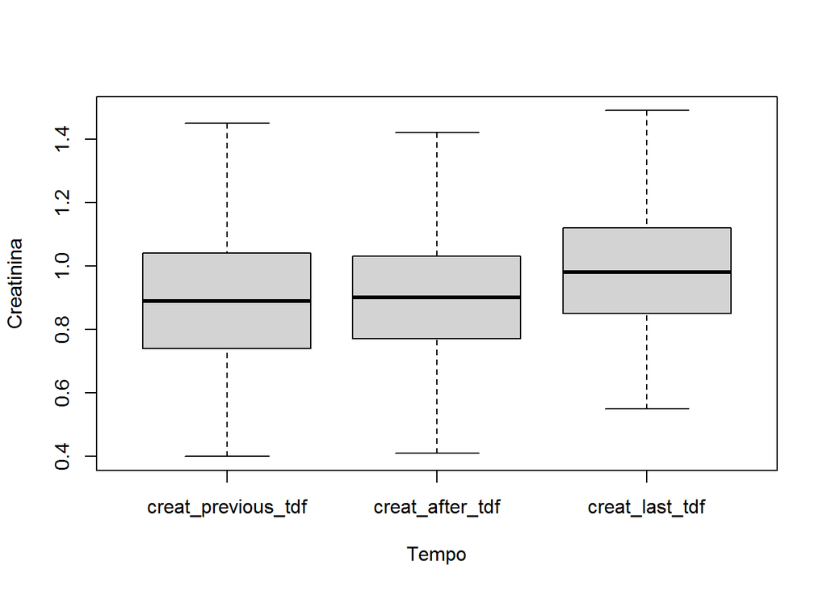

### Histogramas

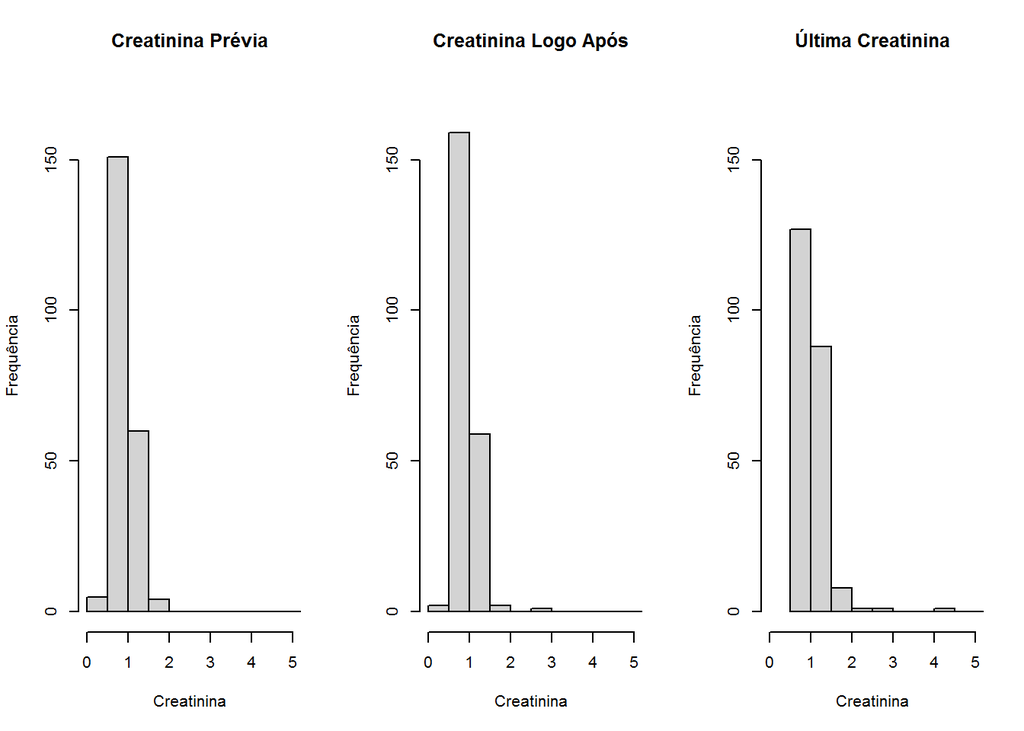

## Conclusão

De acordo com o teste de friedman, **há uma diferença estatística** entre os resultados dos exames de creatinina sérica em relação ao momento da coleta. Com o teste de post-hoc, é possível observar que o **resultado do exame mais recente é diferente estatisticamente dos demais grupos (antes do início e logo após o início)**.

# 4. Análise dos Clearances de Creatinina

Análise estatística entre os resultados da estimação da TFG através do clearance de creatinina obtido pelas fórmulas **MDRD 2** e **CKD-EPI**. Foram analisados: **clearance de creatinina antés do início do tratamento com TDF**,**logo após** e **clearance mais recente**. Os pressupostos normalidade e ausência de outliers foram testados para definir qual o teste mais adequado: **ANOVA de 1 via com medidas repetidas** ou **Teste de Friedman**, usados em situações as quais possuem dados paramétricos ou não paramétricos, respectivamente. Missings foram tratados com valores da mediana imputados.

## Análise de MDRD2

### Normalidade

```
## # A tibble: 3 x 4
##   mdrd_moment         variable statistic        p
##   <fct>               <chr>        <dbl>    <dbl>
## 1 clcr_previous_tdf   mdrd         0.956 2.35e- 6
## 2 clcr_after_tdf_mdrd mdrd         0.869 6.08e-13
## 3 clcr_last_tdf_mdrd2 mdrd         0.925 2.67e- 9
```

p > 0.05 indica que há distribuição normal  
p < 0.05 indica que **não** há distribuição normal

### Outliers

```
## # A tibble: 24 x 5
##    mdrd_moment       record_id  mdrd is.outlier is.extreme
##    <fct>             <fct>     <dbl> <lgl>      <lgl>
##  1 clcr_previous_tdf 3         149.  TRUE       FALSE
##  2 clcr_previous_tdf 29        146.  TRUE       FALSE
##  3 clcr_previous_tdf 49        156.  TRUE       FALSE
##  4 clcr_previous_tdf 58          4.8 TRUE       FALSE
##  5 clcr_previous_tdf 90        155   TRUE       FALSE
##  6 clcr_previous_tdf 126       157.  TRUE       FALSE
##  7 clcr_previous_tdf 151       179.  TRUE       FALSE
##  8 clcr_previous_tdf 250       154.  TRUE       FALSE
##  9 clcr_previous_tdf 254       156.  TRUE       FALSE
## 10 clcr_previous_tdf 260       152.  TRUE       FALSE
## # ... with 14 more rows
## # i Use `print(n = ...)` to see more rows
```

### Teste de Friedman

```
##
##  Friedman rank sum test
##
## data:  mdrd and mdrd_moment and record_id
## Friedman chi-squared = 133.45, df = 2, p-value < 2.2e-16
```

p > 0.05 indica que **não** há diferença entre os grupos  
p < 0.05 indica que há diferença entre os grupos

### Post-hoc

```
##                     clcr_previous_tdf clcr_after_tdf_mdrd
## clcr_after_tdf_mdrd 0.1               -
## clcr_last_tdf_mdrd2 <2e-16            <2e-16
```

### Análise Descritiva

Análise com base na mediana e amplitude interquartil.

```
## # A tibble: 3 x 5
##   mdrd_moment         variable     n median   iqr
##   <fct>               <chr>    <dbl>  <dbl> <dbl>
## 1 clcr_previous_tdf   mdrd       221   86    29.6
## 2 clcr_after_tdf_mdrd mdrd       224   83.2  30.2
## 3 clcr_last_tdf_mdrd2 mdrd       227   73.5  25.5
```

### Boxplot

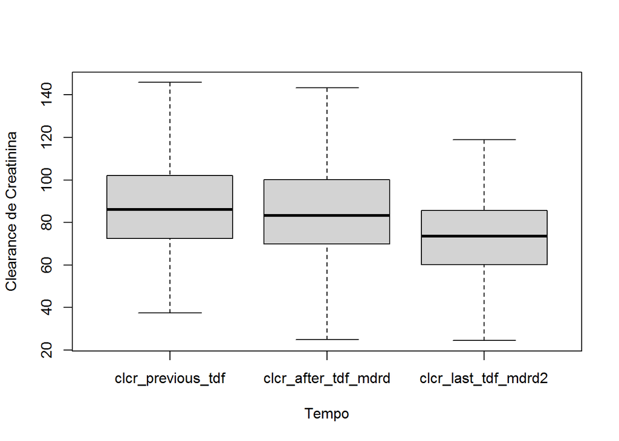

### Histograma

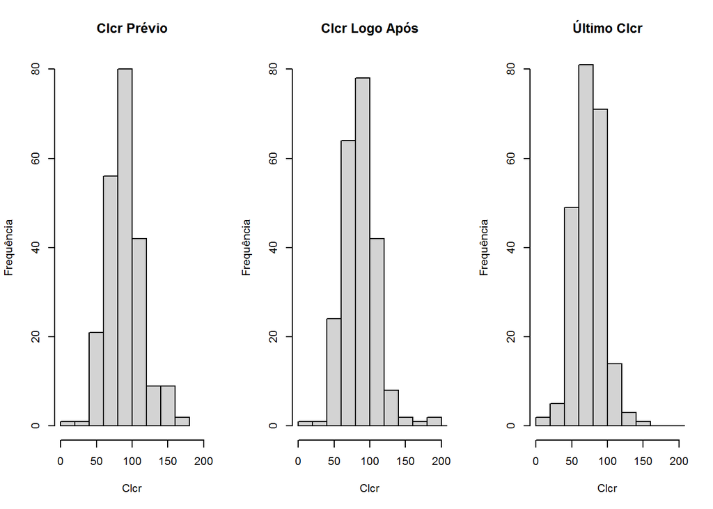

## Análise de CKD-EPI

### Normalidade

```
## # A tibble: 3 x 4
##   ckd_moment            variable statistic        p
##   <fct>                 <chr>        <dbl>    <dbl>
## 1 clcr_previous_tdf_ckd ckd          0.972 0.000250
## 2 clcr_after_tdf_ckd    ckd          0.980 0.00281
## 3 clcr_last_tdf_ckd     ckd          0.989 0.0879
```

p > 0.05 indica que há distribuição normal  
p < 0.05 indica que **não** há distribuição normal

### Outliers

```
## # A tibble: 9 x 5
##   ckd_moment            record_id   ckd is.outlier is.extreme
##   <fct>                 <fct>     <dbl> <lgl>      <lgl>
## 1 clcr_previous_tdf_ckd 58          4.9 TRUE       TRUE
## 2 clcr_previous_tdf_ckd 62         40   TRUE       FALSE
## 3 clcr_after_tdf_ckd    33        147.  TRUE       FALSE
## 4 clcr_after_tdf_ckd    58          6.1 TRUE       FALSE
## 5 clcr_after_tdf_ckd    128        26.4 TRUE       FALSE
## 6 clcr_after_tdf_ckd    253        39.2 TRUE       FALSE
## 7 clcr_last_tdf_ckd     8          17.5 TRUE       FALSE
## 8 clcr_last_tdf_ckd     58          5.4 TRUE       FALSE
## 9 clcr_last_tdf_ckd     261       144.  TRUE       FALSE
```

### Teste de Friedman

```
##
##  Friedman rank sum test
##
## data:  ckd and ckd_moment and record_id
## Friedman chi-squared = 177.45, df = 2, p-value < 2.2e-16
```

p > 0.05 indica que **não** há diferença entre os grupos  
p < 0.05 indica que há diferença entre os grupos

### Post-hoc

```
##                    clcr_previous_tdf_ckd clcr_after_tdf_ckd
## clcr_after_tdf_ckd 0.026                 -
## clcr_last_tdf_ckd  <2e-16                <2e-16
```

### Análise Descritiva

Análise com base na mediana e amplitude interquartil.

```
## # A tibble: 3 x 5
##   ckd_moment            variable     n median   iqr
##   <fct>                 <chr>    <dbl>  <dbl> <dbl>
## 1 clcr_previous_tdf_ckd ckd        221   98.8  25.3
## 2 clcr_after_tdf_ckd    ckd        224   95.7  26.3
## 3 clcr_last_tdf_ckd     ckd        227   82.5  30.5
```

### Boxplot

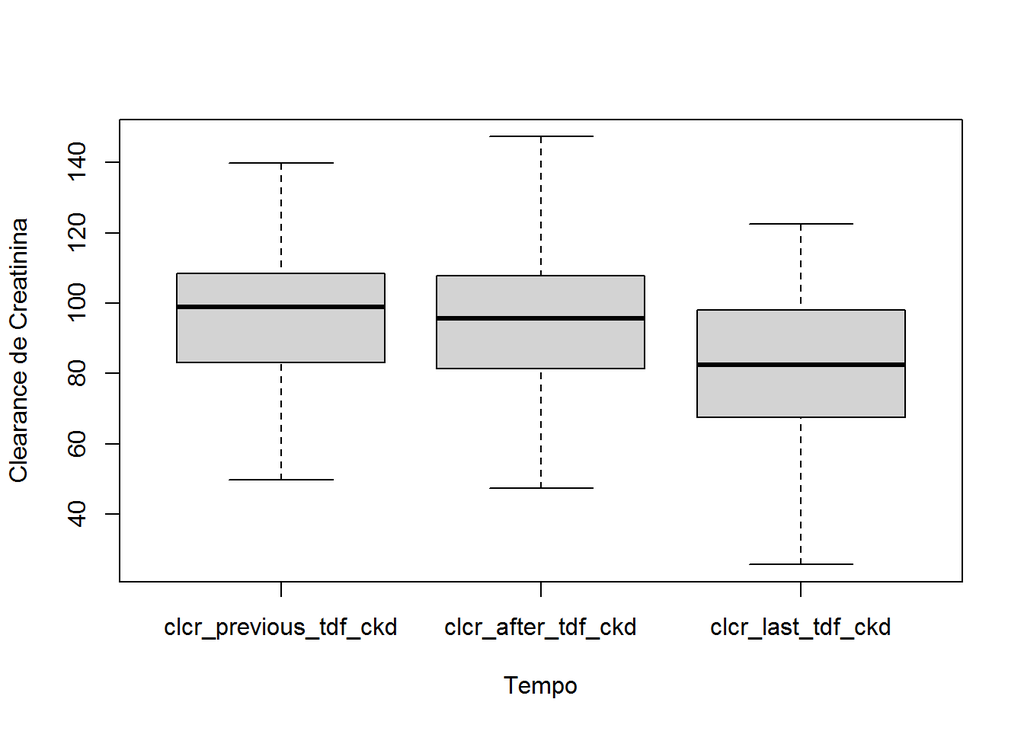

### Histograma

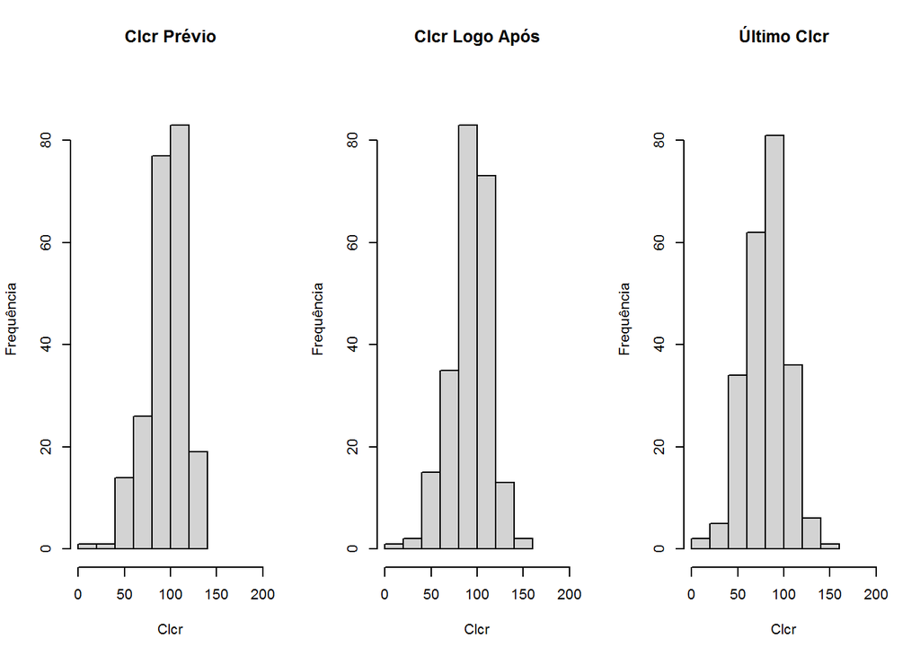

## Conclusão

De acordo com o teste de friedman, **há uma diferença estatística** entre os resultados dos clearances em relação ao momento da coleta de creatinina. Com o teste de post-hoc, é possível observar que o **resultado do clearance mais recente é diferente estatisticamente dos demais grupos (antes do início e logo após o início)**, para ambas as calculadoras: **MDRD2** e **CKD-EPI**.

# 5. Análise das Calculadoras

Análise estatística entre os clearances de creatinina obtidos por três calculadoras distintas: **MDRD 2**, **Cockcroft-Gault** e **CKD-EPI**, a fim de verificar se há correlação entre as variáveis e sua intensidade. Os pressupostos de ausência de outliers, normalidade, homocedasticidade e relação linear foram testados para definir o teste mais adequado: **Correlação de Pearson** ou **Correlações de Spearman/Kendall**, usados em situações as quais possuem dados paramétricos ou não paramétricos, respectivamente.

## Pressupostos

### Normalidade

```
##
##  Shapiro-Wilk normality test
##
## data:  dados$clcr_last_tdf_cg
## W = 0.98243, p-value = 0.006425
```

```
##
##  Shapiro-Wilk normality test
##
## data:  dados$clcr_last_tdf_mdrd2
## W = 0.92537, p-value = 2.669e-09
```

```
##
##  Shapiro-Wilk normality test
##
## data:  dados$clcr_last_tdf_ckd
## W = 0.98923, p-value = 0.0879
```

```
##
##  Shapiro-Wilk normality test
##
## data:  dados$clcr_after_tdf_ckd
## W = 0.9799, p-value = 0.002806
```

```
##
##  Shapiro-Wilk normality test
##
## data:  dados$clcr_after_tdf_mdrd
## W = 0.86922, p-value = 6.077e-13
```

```
##
##  Shapiro-Wilk normality test
##
## data:  dados$clcr_previous_tdf
## W = 0.95552, p-value = 2.353e-06
```

```
##
##  Shapiro-Wilk normality test
##
## data:  dados$clcr_previous_tdf_ckd
## W = 0.97232, p-value = 0.0002503
```

p > 0.05 indica que há distribuição normal  
p < 0.05 indica que **não** há distribuição normal

### Outliers

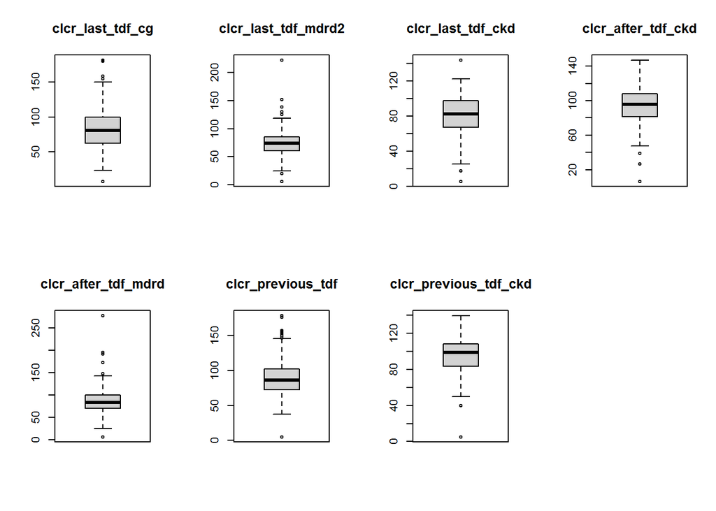

### Homocedasticidade

Verificação gráfica/visual: dados devem estar distribuídos igualmente, formando um “retângulo”.

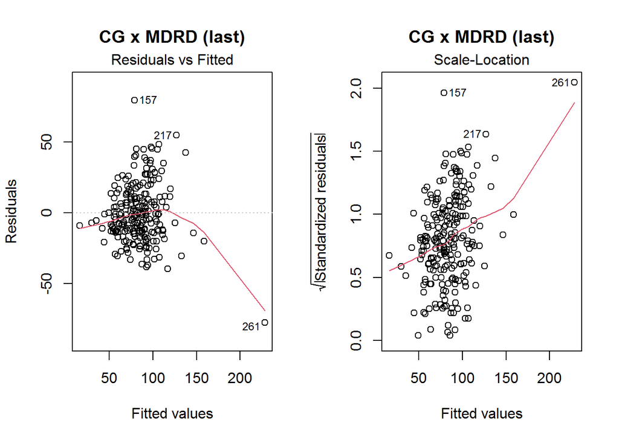

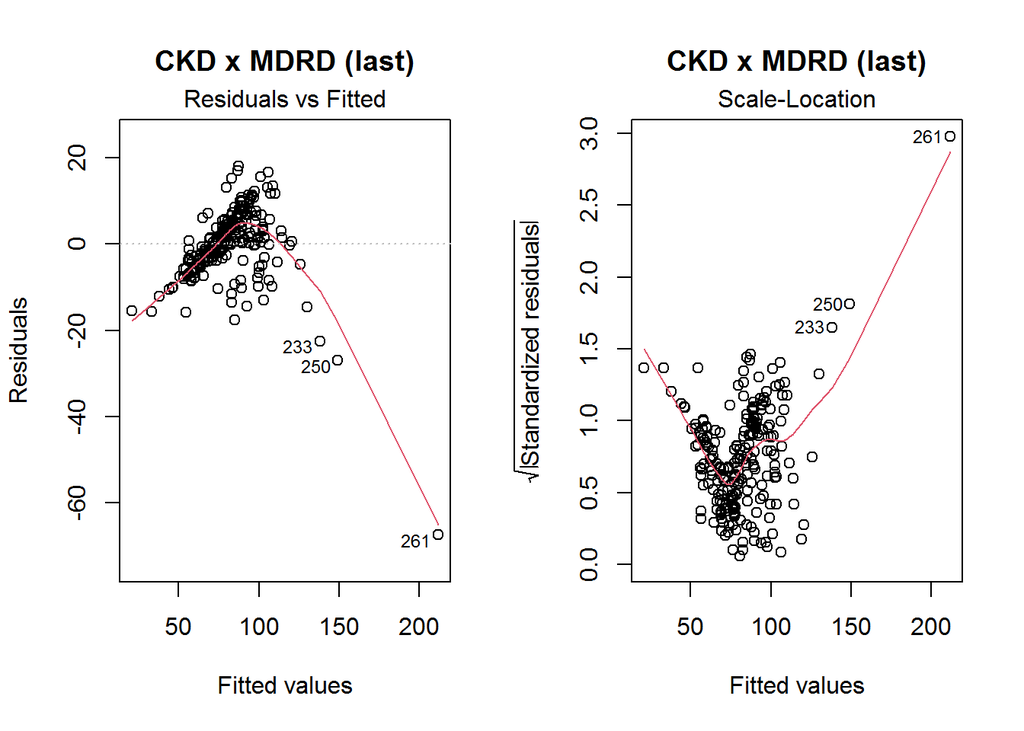

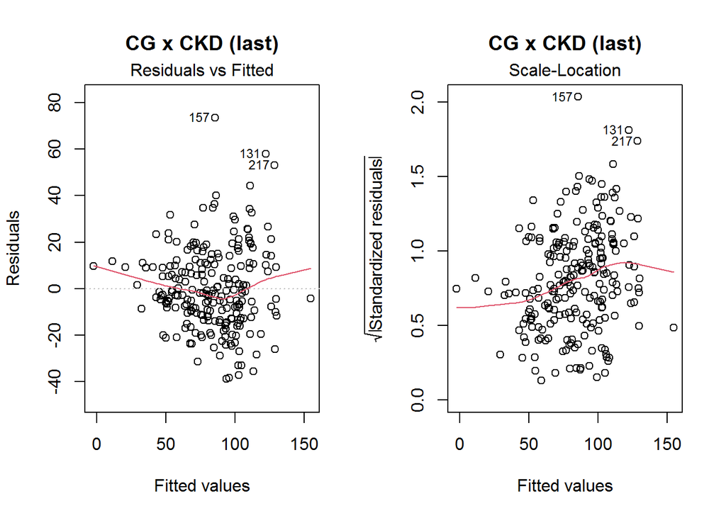

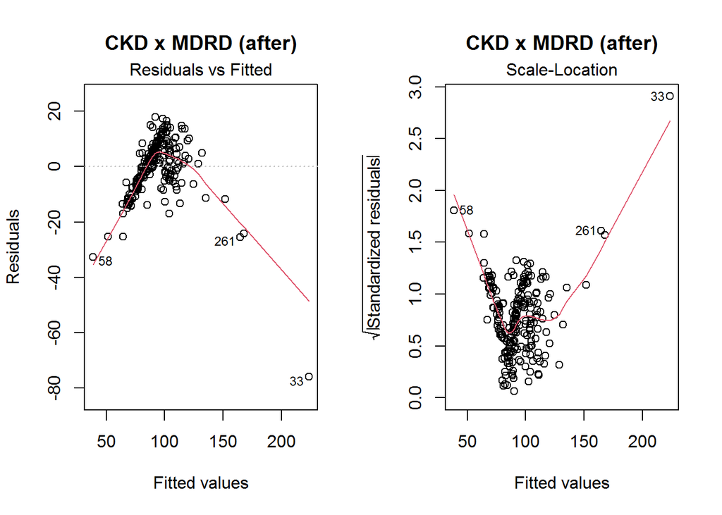

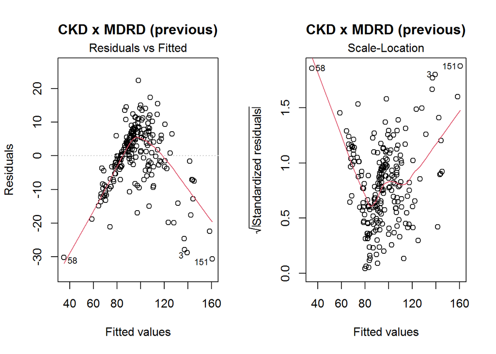

### Relação Linear

Verificar através da dispersão dos dados se há uma relação linear.

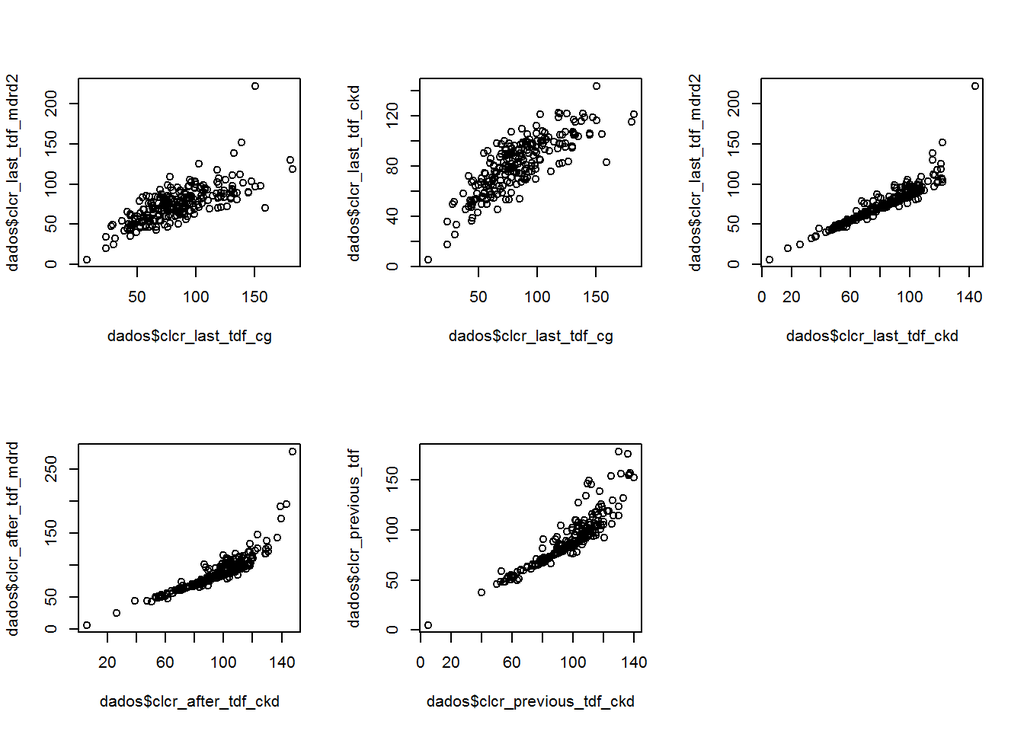

## Correlação de Spearman

p > 0.05 indica coeficiente de correlação **igual** a zero.  
p < 0.05 indica coeficiente de correlação **diferente** de zero **(apresenta correlação)**.

### Cockcroft-Gault x MDRD2 (last)

```
##
##  Spearman's rank correlation rho
##
## data:  dados$clcr_last_tdf_cg and dados$clcr_last_tdf_mdrd2
## S = 487244, p-value < 2.2e-16
## alternative hypothesis: true rho is not equal to 0
## sample estimates:
##      rho
## 0.750064
```

### Cockcroft-Gault x CKD-EPI (last)

```
##
##  Spearman's rank correlation rho
##
## data:  dados$clcr_last_tdf_cg and dados$clcr_last_tdf_ckd
## S = 357239, p-value < 2.2e-16
## alternative hypothesis: true rho is not equal to 0
## sample estimates:
##       rho
## 0.8167512
```

### CKD-EPI x MDRD2 (last)

```
##
##  Spearman's rank correlation rho
##
## data:  dados$clcr_last_tdf_ckd and dados$clcr_last_tdf_mdrd2
## S = 79575, p-value < 2.2e-16
## alternative hypothesis: true rho is not equal to 0
## sample estimates:
##       rho
## 0.9591814
```

### CKD-EPI x MDRD2 (after)

```
##
##  Spearman's rank correlation rho
##
## data:  dados$clcr_after_tdf_ckd and dados$clcr_after_tdf_mdrd
## S = 116764, p-value < 2.2e-16
## alternative hypothesis: true rho is not equal to 0
## sample estimates:
##       rho
## 0.9376663
```

### CKD-EPI x MDRD2 (previous)

```
##
##  Spearman's rank correlation rho
##
## data:  dados$clcr_previous_tdf_ckd and dados$clcr_previous_tdf
## S = 115797, p-value < 2.2e-16
## alternative hypothesis: true rho is not equal to 0
## sample estimates:
##       rho
## 0.9356303
```

## Gráficos de Dispersão

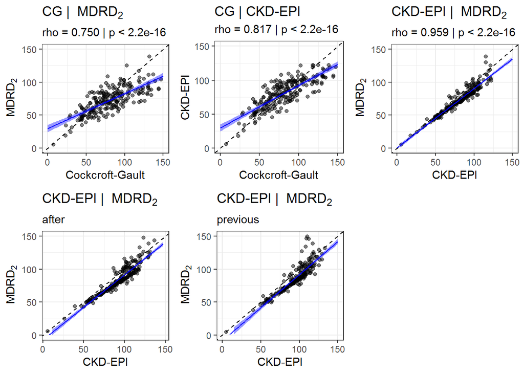

## Conclusão

De acordo com o teste de correlação de spearman, **há uma correlação forte entre todos clearances de creatinina obtidos pelas fórmulas MDRD 2, Cockcroft-Gault e CKD-EPI**.

# 6. Conclusão Final

No total, foram analisados 232 pacientes, dentre os quais **80** tem indicação para TAF e **145** não tem indicação para TAF e permanecerão com TDF.

# 7. Figuras

## Tabelas

**Tabela 1** - Características dos pacientes de acordo com os grupos de tratamento

| **Características** | **N** | **Total**<sup>1</sup> | **Grupos de Tratamento** **TAF**<sup>1</sup> | **Grupos de Tratamento** **TDF**<sup>1</sup> | **p**<sup>2</sup> |  |
| --- | --- | --- | --- | --- | --- | --- |
| Demográficas |  |  |  |  |  |  |
| Idade | 225 | 57 (46, 68) | 65 (53, 70) | 52 (44, 64) |  | <0.001 |
| IMC | 225 | 26.0 (23.5, 28.6) | 26.2 (23.8, 28.8) | 25.9 (23.4, 28.4) | 0.3 |  |
| Homem | 225 | 147 (65%) | 46 (57%) | 101 (70%) | 0.067 |  |
| Etnia | 214 |  |  |  | 0.7 |  |
| Branca |  | 158 (74%) | 59 (79%) | 99 (71%) |  |  |
| Negra |  | 14 (6.5%) | 3 (4.0%) | 11 (7.9%) |  |  |
| Amarela |  | 28 (13%) | 9 (12%) | 19 (14%) |  |  |
| Parda |  | 14 (6.5%) | 4 (5.3%) | 10 (7.2%) |  |  |
| Clínicas |  |  |  |  |  |  |
| Exposição à Lamivudina | 225 | 121 (54%) | 80 (100%) | 41 (28%) | <0.001 |  |
| Cirrose | 224 | 57 (25%) | 39 (49%) | 18 (12%) | <0.001 |  |
| Última TFGe <60 | 214 | 65 (30%) | 40 (53%) | 25 (18%) | <0.001 |  |
| Redução da TFGe >25% | 209 | 51 (24%) | 28 (37%) | 23 (17%) | 0.002 |  |
| Osteoporose | 224 | 19 (8.5%) | 12 (15%) | 7 (4.9%) | 0.009 |  |
| Comorbidades |  |  |  |  |  |  |
| Sem Comorbidades | 225 | 114 (51%) | 37 (46%) | 77 (53%) | 0.3 |  |
| Diabetes, tipo I ou II | 225 | 45 (20%) | 19 (24%) | 26 (18%) | 0.3 |  |
| Dislipidemia | 225 | 35 (16%) | 15 (19%) | 20 (14%) | 0.3 |  |
| Hipertensão | 225 | 90 (40%) | 38 (48%) | 52 (36%) | 0.088 |  |
| Creatinina Sérica |  |  |  |  |  |  |
| Prévia | 219 | 0.89 (0.74, 1.04) | 0.89 (0.70, 1.04) | 0.88 (0.76, 1.03) | 0.8 |  |
| Após | 220 | 0.90 (0.77, 1.03) | 0.92 (0.77, 1.08) | 0.90 (0.77, 0.99) | 0.4 |  |
| Última | 222 | 0.99 (0.85, 1.12) | 1.03 (0.88, 1.26) | 0.98 (0.83, 1.09) | 0.023 |  |

<sup>1</sup> Median (IQR); n (%)  
<sup>2</sup> Wilcoxon rank sum test; Pearson's Chi-squared test; Fisher's exact test

**Tabela 2** - Estimativas da taxa de filtração glomerular por MDRD², CKD-EPI e Cockcroft-Gault

| **Características** | **N** | **Total**<sup>1</sup> | **Grupos de Tratamento** **TAF**<sup>1</sup> | **Grupos de Tratamento** **TDF**<sup>1</sup> | **p**<sup>2</sup> |  |
| --- | --- | --- | --- | --- | --- | --- |
| MDRD² |  |  |  |  |  |  |
| Prévio | 219 | 86 (72, 102) | 84 (66, 93) | 88 (77, 104) |  | 0.022 |
| Após | 220 | 83 (70, 100) | 78 (61, 94) | 86 (75, 101) | 0.001 |  |
| Último | 222 | 73 (60, 87) | 62 (51, 82) | 78 (68, 90) | <0.001 |  |
| Redução da TFGe | 217 | 13 (4, 24) | 20 (8, 28) | 11 (2, 21) | <0.001 |  |
| CKD-EPI |  |  |  |  |  |  |
| Prévio | 219 | 99 (83, 108) | 93 (77, 105) | 100 (89, 111) | 0.008 |  |
| Após | 220 | 96 (81, 108) | 89 (69, 103) | 98 (87, 111) | <0.001 |  |
| Último | 222 | 82 (67, 98) | 68 (58, 91) | 87 (75, 100) | <0.001 |  |
| Redução da TFGe | 217 | 12 (5, 22) | 17 (8, 27) | 10 (4, 17) | <0.001 |  |
| Cockcroft-Gault |  |  |  |  |  |  |
| Último | 222 | 81 (63, 101) | 68 (51, 91) | 86 (71, 107) | <0.001 |  |

<sup>1</sup> Median (IQR)  
<sup>2</sup> Wilcoxon rank sum test

**Tabela 3** - Características dos pacientes de acordo com o critério ósseo

| **Características** | **Com alteração óssea**<sup>1</sup> | **Sem alteração óssea**<sup>1</sup> | **p-value**<sup>2</sup> |
| --- | --- | --- | --- |
| Idade | 65 (53, 71) | 54 (45, 67) | 0.001 |
| Cirrose | 12 (26%) | 45 (25%) | 0.8 |
| Sem Comorbidade | 16 (35%) | 100 (55%) | 0.016 |
| Diabetes | 13 (28%) | 34 (19%) | 0.15 |
| Dislipidemia | 9 (20%) | 28 (15%) | 0.5 |
| Hipertensão | 26 (57%) | 65 (36%) | 0.009 |
| Exposição à Lamivudina | 27 (59%) | 99 (54%) | 0.6 |
| Última TFGe <60 | 25 (57%) | 40 (23%) | <0.001 |
| Redução da TFGe >25% | 15 (37%) | 37 (22%) | 0.051 |

<sup>1</sup> Median (IQR); n (%)  
<sup>2</sup> Wilcoxon rank sum test; Pearson's Chi-squared test

**Tabela 4** - Características dos pacientes de acordo com o critério renal

| **Características** | **Com alteração renal**<sup>1</sup> | **Sem alteração renal**<sup>1</sup> | **p-value**<sup>2</sup> |
| --- | --- | --- | --- |
| Idade | 64 (50, 71) | 53 (44, 63) | <0.001 |
| Cirrose | 24 (24%) | 31 (27%) | 0.6 |
| Sem Comorbidade | 48 (48%) | 62 (53%) | 0.4 |
| Diabetes | 28 (28%) | 17 (15%) | 0.018 |
| Dislipidemia | 19 (19%) | 15 (13%) | 0.2 |
| Hipertensão | 46 (46%) | 42 (36%) | 0.2 |
| Exposição à Lamivudina | 58 (57%) | 62 (53%) | 0.6 |
| Osteoporose | 12 (12%) | 7 (6.0%) | 0.13 |

<sup>1</sup> Median (IQR); n (%)  
<sup>2</sup> Wilcoxon rank sum test; Pearson's Chi-squared test

**Tabela 5** - Características dos pacientes de acordo com o critério cirrose

| **Características** | **Com cirrose**<sup>1</sup> | **Sem cirrose**<sup>1</sup> | **p-value**<sup>2</sup> |
| --- | --- | --- | --- |
| Idade | 64 (54, 70) | 54 (44, 66) | <0.001 |
| Sem Comorbidade | 29 (51%) | 87 (51%) | >0.9 |
| Diabetes | 13 (23%) | 34 (20%) | 0.6 |
| Dislipidemia | 8 (14%) | 29 (17%) | 0.6 |
| Hipertensão | 24 (42%) | 67 (39%) | 0.7 |
| Exposição à Lamivudina | 39 (68%) | 87 (51%) | 0.019 |
| Osteoporose | 7 (12%) | 12 (7.0%) | 0.3 |
| Última TFGe <60 | 18 (32%) | 47 (29%) | 0.7 |
| Redução da TFGe >25% | 9 (17%) | 43 (27%) | 0.13 |

<sup>1</sup> Median (IQR); n (%)  
<sup>2</sup> Wilcoxon rank sum test; Pearson's Chi-squared test; Fisher's exact test

## Boxplots

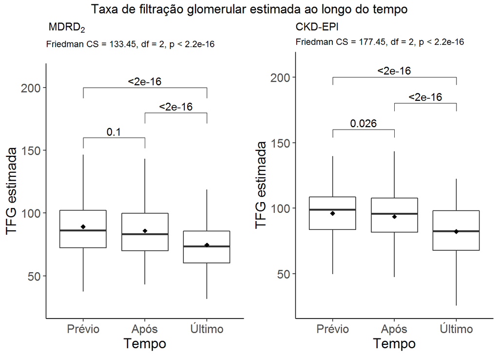

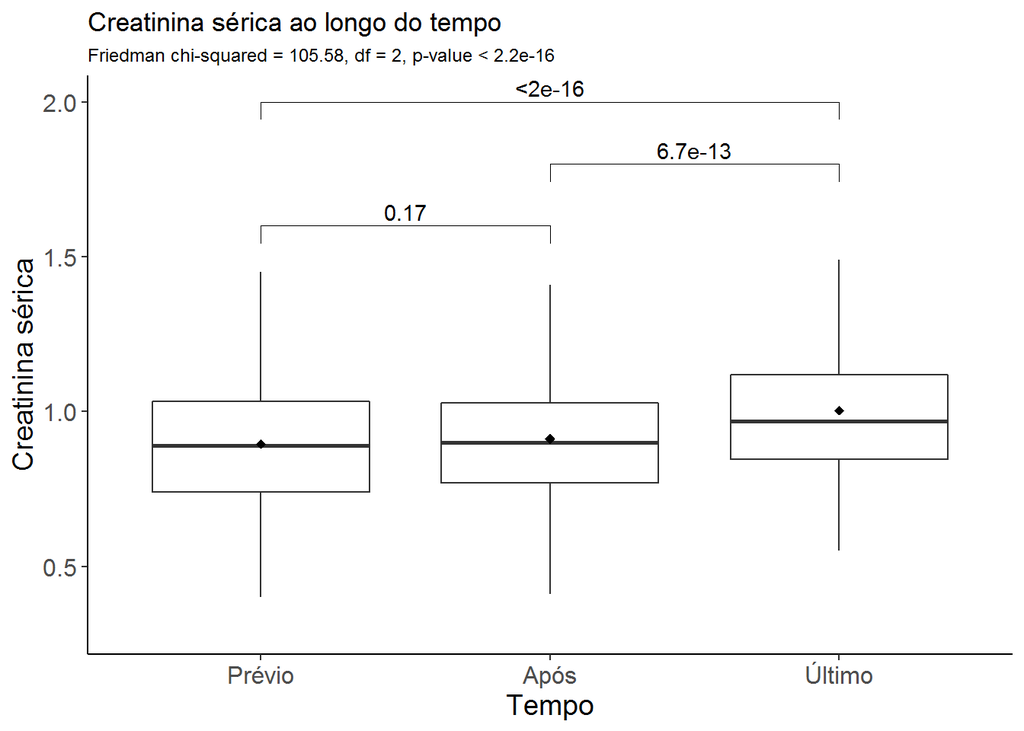

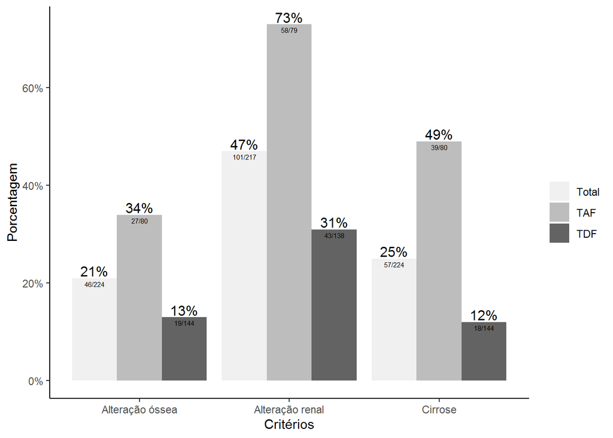

## Gráficos de Barra

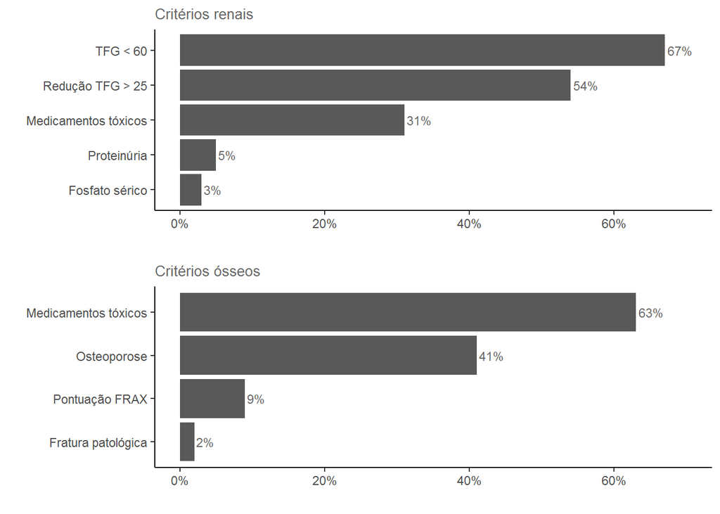

## Gráficos de Dispersão

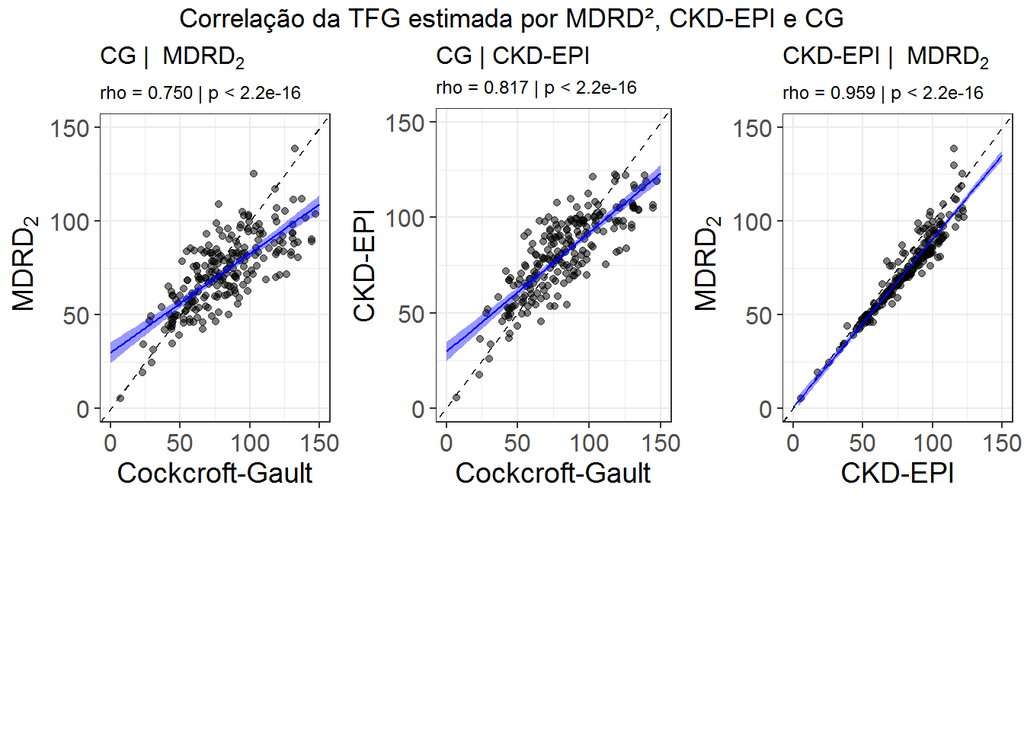